# Josh Lee’s BEES3041 Code

# Libaries used:

```r
library(dplyr)
library(ggplot2)
library(sf)
library(tidyverse)
library(anchors)
library(readr)
library(tidyverse)
library(lubridate)
library(rnaturalearth)
library(mgcv)
```

# Split files using a linux command line and read in first file (baa)

Since the data from eBird was so large, we split into 230 files with 100,000 rows

|  | GLOBAL.UNIQUE.IDENTIFIER | LAST.EDITED.DATE | TAXONOMIC.ORDER | CATEGORY | COMMON.NAME | SCIENTIFIC.NAME | SUBSPECIES.COMMON.NAME | SUBSPECIES.SCIENTIFIC.NAME | OBSERVATION.COUNT | BREEDING.BIRD.ATLAS.CODE | BREEDING.BIRD.ATLAS.CATEGORY | AGE.SEX | COUNTRY | COUNTRY.CODE | STATE | STATE.CODE | COUNTY | COUNTY.CODE | IBA.CODE | BCR.CODE | USFWS.CODE | ATLAS.BLOCK | LOCALITY | LOCALITY.ID | LOCALITY.TYPE | LATITUDE | LONGITUDE | OBSERVATION.DATE | TIME.OBSERVATIONS.STARTED | … |
| --- | --- | --- | --- | --- | --- | --- | --- | --- | --- | --- | --- | --- | --- | --- | --- | --- | --- | --- | --- | --- | --- | --- | --- | --- | --- | --- | --- | --- | --- | --- |
| 1 | URN:CornellLabOfOrnithology:EBIRD:OBS228353471 | 2017-10-23 17:29:24 | 6094 | species | Australian Pratincole | Stiltia isabella |  |  | X |  |  |  | Australia | AU | Northern Territory | AU-NT | Barkly | AU-NT-BAR | NA | NA | NA | NA | Barrow Creek 10' Cell | L2561960 | P | -21.58333 | 133.9167 | 1980-09-30 |  | … |
| 2 | URN:CornellLabOfOrnithology:EBIRD:OBS653431714 | 2020-02-17 02:24:14 | 554 | species | Chestnut Teal | Anas castanea |  |  | 2 |  |  |  | Australia | AU | New South Wales | AU-NSW | Ryde | AU-NSW-RYD | NA | NA | NA | NA | Lane Cove National Park | L1930244 | H | -33.77215 | 151.1250 | 1993-04-14 |  | … |
| 3 | URN:CornellLabOfOrnithology:EBIRD:OBS207735733 | 2020-02-22 00:56:23 | 17702 | species | Australian Logrunner | Orthonyx temminckii |  |  | 5 |  |  |  | Australia | AU | Queensland | AU-QLD | Scenic Rim | AU-QLD-SCE | NA | NA | NA | NA | Lamington National Park--Binna Burra | L921547 | H | -28.19913 | 153.1880 | 1994-10-11 | 11:00:00 | … |
| 4 | URN:CornellLabOfOrnithology:EBIRD:OBS228708911 | 2020-02-28 23:09:36 | 17297 | species | New Holland Honeyeater | Phylidonyris novaehollandiae |  |  | X |  |  |  | Australia | AU | Victoria | AU-VIC | Surf Coast | AU-VIC-SUR | NA | NA | NA | NA | Point Addis | L921929 | H | -38.39479 | 144.2525 | 1994-09-16 |  | … |
| 5 | URN:CornellLabOfOrnithology:EBIRD:OBS375770901 | 2017-10-24 13:43:06 | 11548 | species | Galah | Eolophus roseicapilla |  |  | X |  |  |  | Australia | AU | Western Australia | AU-WA | Jerramungup | AU-WA-JER | NA | NA | NA | NA | South Coast Highway (-33.83148, 119.25389) | L4294248 | P | -33.83136 | 119.2539 | 1999-09-09 |  | … |
| 6 | URN:CornellLabOfOrnithology:EBIRD:OBS679922534 | 2020-03-22 19:14:26 | 18890 | species | Gray Butcherbird | Cracticus torquatus |  |  | 1 |  |  |  | Australia | AU | New South Wales | AU-NSW | Coonamble | AU-NSW-COO | NA | NA | NA | NA | Warrumbungle National Park | L921606 | H | -31.27741 | 148.9986 | 1998-09-30 |  | … |

# Filtering unwanted checklists

## Protocol used for filtering and selecting:

Removed Incomplete checklists  
Removed checklists Duration.Minutes less than 10m and more than 5hrs  
Removed Checklists Effort.Distance more than 10km  
Keeping Locality ID, Sampling event identifier, Lat and Long, Date  
Removing duplicates

```r
baatrimmed<- baa %>%
  filter(ALL.SPECIES.REPORTED==1, EFFORT.DISTANCE.KM<10, DURATION.MINUTES<300, DURATION.MINUTES>10) %>%
  select(SAMPLING.EVENT.IDENTIFIER, LOCALITY.ID, LATITUDE, LONGITUDE, OBSERVATION.DATE) %>%
  distinct()
```

[output not shown]

# Spacial Processing steps:

## Read in fire shapefile

National Indicative Aggregated Fire Extent Datasets from Department of Agriculture Water and the Environment

```r
fireshape<- st_read("Data/Raw/National_Indicative_Aggregated_Fire_Extent_Dataset_v20200211/National_Indicative_Aggregated_Fire_Extent_Dataset_v20200211.shp")
```

## Map of shapefile

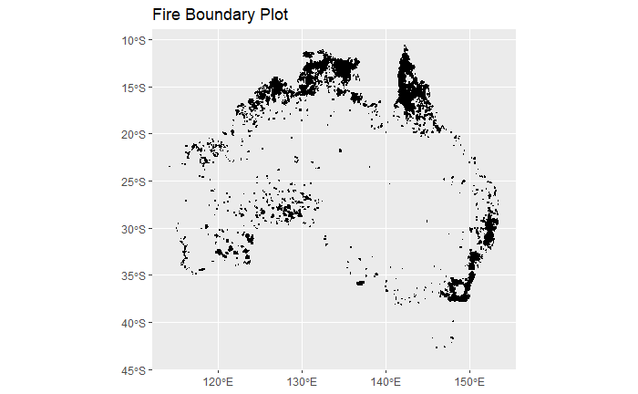

```r
ggplot() +
  geom_sf(data = fireshape, size = 0.1, color = "black", fill = "black") +
  ggtitle("Fire Boundary Plot") +
  coord_sf()
```

## Convert ebird checklists to sf object with CRS code from fire shapefile

Make the eBird data a sf object, then match CRS(Coordinate Reference System) with fire shapefile

```r
ebird_points <- st_as_sf(baatrimmed, coords=c("LONGITUDE", "LATITUDE"), crs=st_crs(fireshape))
```